# Étude statistique pour caractérisation et typologie des produits en fonction de leur paramètre de qualité

Yesmine Bellalah , Amal Khiar Eddine

1 février 2016

# Étude statistique pour caractérisation et typologie des produits en fonction de leur paramètre de qualité

*** L’analyse sensorielle est un ensemble de méthodes permettant de mesurer les perceptions sensorielles (vue, ouïe, odorat, goût, toucher). Elle sera mise en ouvre afin de rendre le produit plus « séduisant » pour le client.

*** Le marketing sensoriel est une technique marketing qui sollicite un ou plusieurs des cinq sens du consommateur. Son objectif est de séduire le consommateur dans le but d’influencer favorablement son comportement vis-à-vis d’un produit.

# I)Exploration des donées :

DESCRIPTION DE LA BASE DES DONNEES:

Nous disposons d’un jeu de données de 8 biscuits dont 4 français (F1, F2,F3,F4) et 4 pakistanais (P1,P2,P3,P4). Une évaluation sensorielle a été organisée pour caractériser ces produits. Un jury de 12 experts entrainés à évaluer ces produits lors de 2 séances de dégustation et selon 23 descripteurs sensoriels. Les notes varient entre 0 et 10 , 0 signifie saveur faible et 10 signifie saveur très imporatnte.

# II) Etude descriptive

1. Visualisation des différences entre juges ,séance, produits

   ```
   a) Effet juge :
   ```

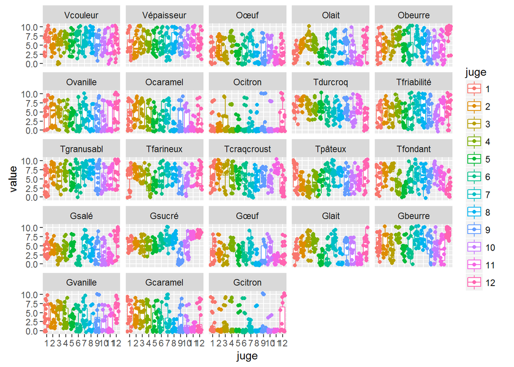

*Ces boxplots mettent en évidence les préférence des juges envers tous les descripteurs sensorielles .

```r
library(plotly)
Gc=plot_ly(data,x=Gcitron,color=juge, type="box")
 Gc
```

[interactive chart not shown]

La majorité des juges n’ont pas apprecié le gout citron .

```r
Gs=plot_ly(data,x=Gsucré,color=juge, type="box")
Gs
```

[interactive chart not shown]

Les juges ont distingué le gout sucré.

b)- Effet produit :

```r
p1=plot_ly(data ,x=Gcitron,color=produit, type="box")
p1
```

[interactive chart not shown]

```r
p2=plot_ly(data,x=Gsucré,color=produit, type="box")
p2
```

[interactive chart not shown]

```r
p3=plot_ly(data,x=Olait,color=produit, type="box")
p3
```

[interactive chart not shown]

On remarque que les produits français se rassemblent beaucoup mais les produits pakistanais montrent une différence significative.

c)- Effet séance :

[interactive chart not shown]

On remarque la répetabilité des juges d’une seance à l’autre l’effet séance l’emporte peu

4. Visualisation simultanée dynamique :

[bar](http://127.0.0.1:30700/custom/googleVis/BubbleChartID1ba072336fa7.html) [bubble](http://127.0.0.1:30700/custom/googleVis/BubbleChartID1ba07fe73ede.html) [motion](http://127.0.0.1:30700/custom/googleVis/MotionChartID1ba011865df.html)

```r
library( googleVis)
```

```r
bar=gvisBubbleChart(data, idvar="juge", xvar="Vcouleur", yvar="Gcitron", colorvar = "produit", sizevar = "seance", options=list( {hAxis='{minValue:1,maxValue:10}'},width=1200 , height=1000))
plot(bar)
```

```
## starting httpd help server ...
```

```
##  done
```

```r
bubble=gvisBubbleChart(tab_moyen,idvar="produit",xvar="Gcitron",yvar="Vcouleur")
plot(bubble)
trial=read.table(file=file.choose(),header=T,sep=";", dec=",")
attach(trial)
library(survival)
library(doBy)
tab_mean=summaryBy(.~produit+as.numeric(seance),trial,FUN = c(mean),na.rm=TRUE,keep.names=TRUE)

motion=gvisMotionChart(tab_mean, idvar="produit", timevar="seance")
plot(motion)
```

# III)-Analyse multivariée :

# 1)- Analyse en composantes principales “ACP” :

On va travailler sur la denière base construite qui résume la 1ère base importée en calculant la moyenne des notes données par les experts pendant les deux séances de dégustation pour tous les descripteurs sensoriels de chaque produit français et pakistanais.

Dans notre base on a 23 variables quantitatives et une variable qualitative (24)  
On peut utiliser la méthode d’analyse en composantes principales comme méthode d’analyse en considérant les 23 premières variables comme des variables actifs et la 24 ème variable comme variable qualitative supplémentaire. *a) Réalisation de l’ACP , cercle de corrélation :*

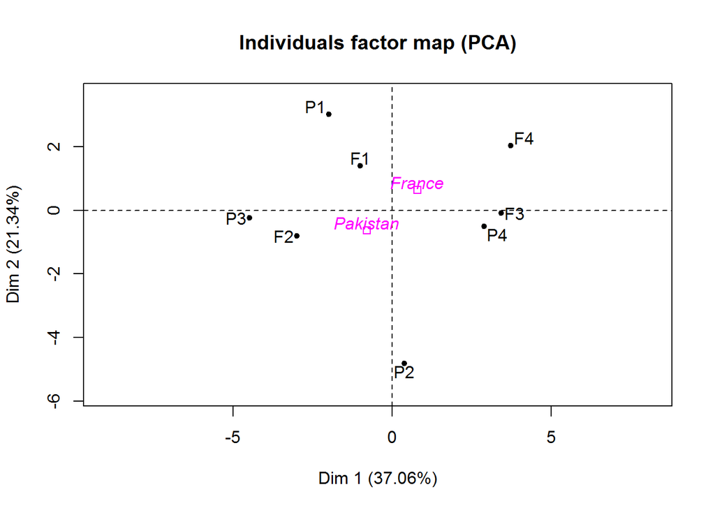

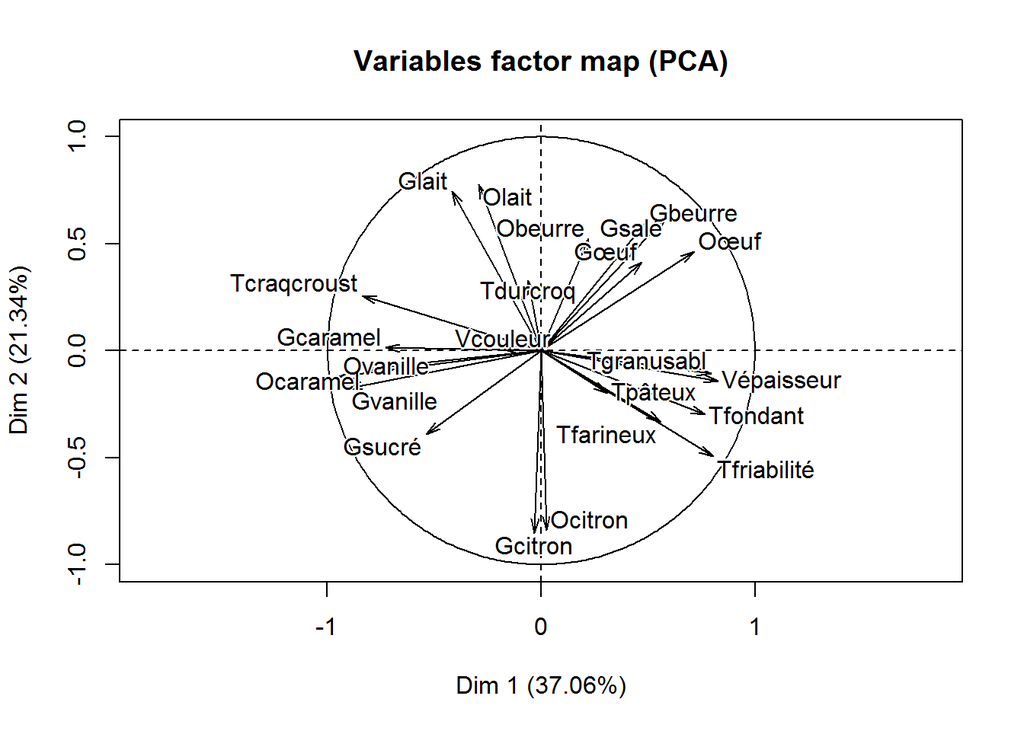

```r
library(FactoMineR)
res.pca=PCA(data3 ,scale.unit=T,quali.sup=24)
```

Une meilleure représentation du cercle de corrélation :

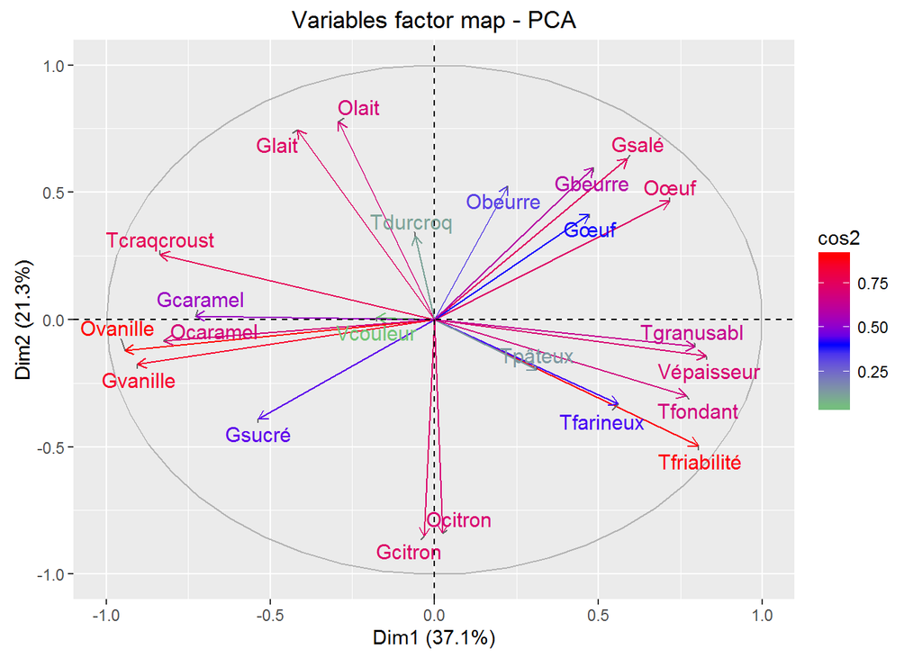

```r
library(ggplot2)
library(grid)
library(factoextra)
fviz_pca_var(res.pca,col.var="cos2")+scale_color_gradient2(low="green",mid="blue",high="red",midpoint=0.4)
```

En regardant le cercle de corrélation on remarque que certaines variables sont fortemenet correlées telles que les variable Ocitron et Gcitron , Olit et Glait , Gvanille et Ovanille , Geuf et Oeuf , Gcaramelet Ocaramel .. ce qui est totalemet normal et prévisible. Il ya d’autres variables qui sont inversement correlées telles que les variables Tcraqcroust et Tgranusabl( c’est normal un biscuit ne peut pas etre croustillant et granleux à la fois) , Gsucré et Gsalé ( logique un biscuit ne peut pas avoir un gout salé et sucré à la fois ) , et il y a des variables qui ne sont pas correlées telles que les variables Oeuf et Glait, Obeuree et Tfarineux …

De plus on remarque des variables qui sont mal representées ( en vert) comme Vcouleur, Tducroq et Tpateux.

```
      **b) Les valeurs propres ( scree plot ):**
```

```r
res.pca$eig
```

```
##        eigenvalue percentage of variance cumulative percentage of variance
## comp 1  8.5236786              37.059472                          37.05947
## comp 2  4.9084429              21.341056                          58.40053
## comp 3  3.9063247              16.984020                          75.38455
## comp 4  2.8800368              12.521899                          87.90645
## comp 5  1.3164671               5.723770                          93.63022
## comp 6  0.9905992               4.306953                          97.93717
## comp 7  0.4744508               2.062830                         100.00000
```

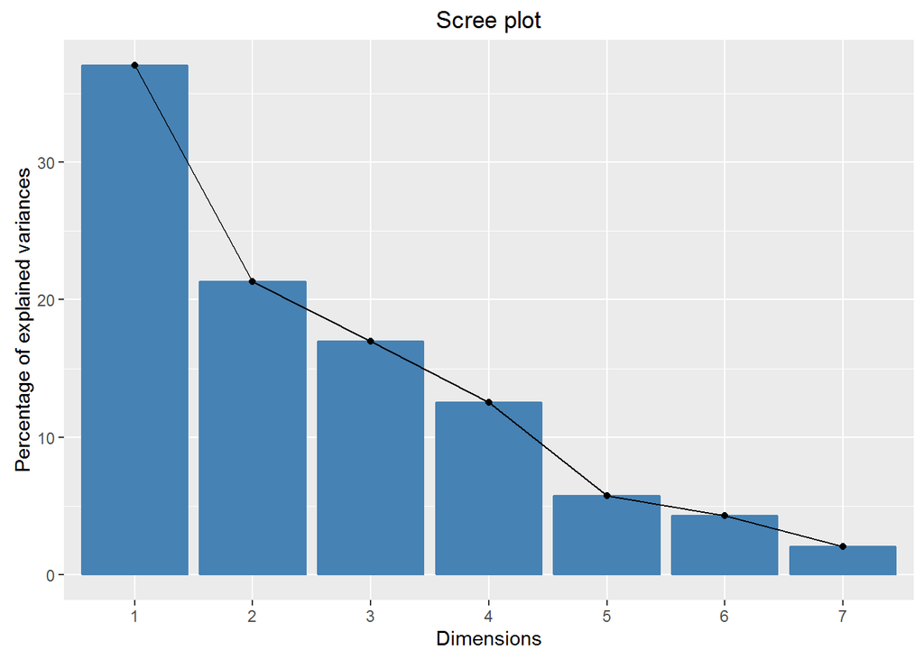

```
       **c) Représentation des produits français et pakistanais:**
```

```r
fviz_screeplot(res.pca)
```

D’aprés le graphe,les produits F3,P3 et P4 sont bien representés sur l’axe1 et Le produit P2 est trés bien representé sur l’axe2 .

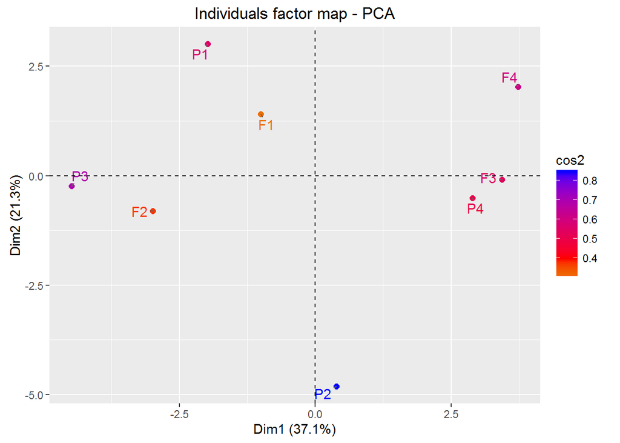

```r
fviz_pca_ind(res.pca,geom=c("point","text"),col.ind="cos2")+scale_color_gradient2(low='green',mid='red',high='blue',midpoint=0.4)
```

Une meilleure représentation qui met en evidence la 24ème variable comme variable qualitative supplémentaire

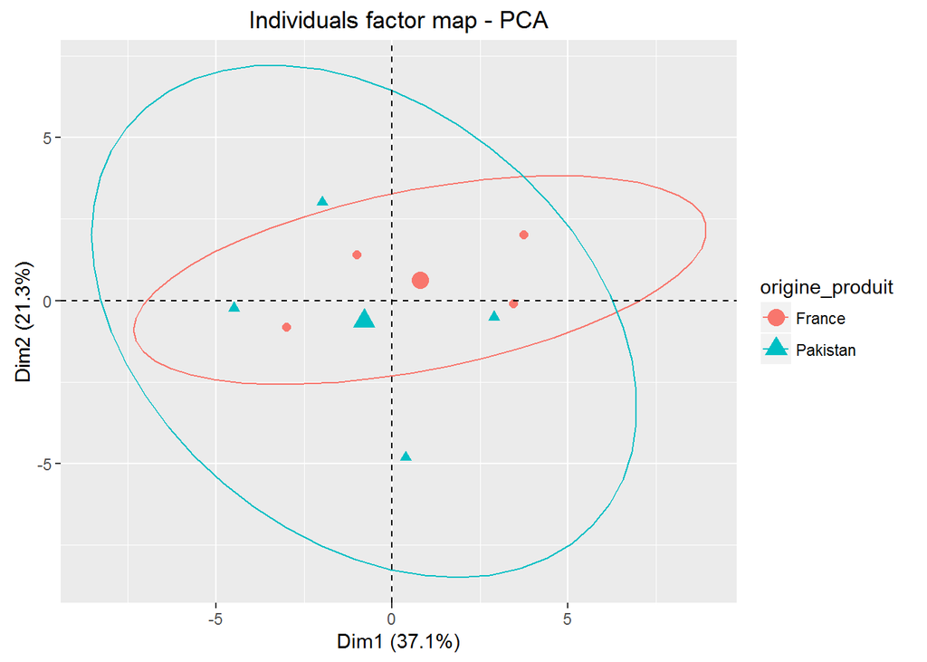

```
        **d) Les ellipses de confiance :**
```

```r
fviz_pca_ind(res.pca, habillage=24,label=T,addEllipses=TRUE, ellipse.level=0.95, alpha.ind=0.5)+theme_gray()
```

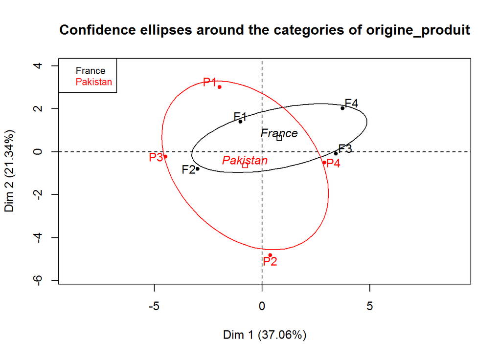

```r
plotellipses(res.pca)
```

```
        **e) Contribution des produits :**
```

Les produits P3(29,44%),F4(20.43%),F3(17.29%),F2(13.12%) sont les produits qui contribuent le plus dans la construction de l’axe 1.

```r
round(res.pca$ind$contrib[,1],digits = 2)
```

```
##    F1    F2    F3    F4    P1    P2    P3    P4
##  1.46 13.12 17.29 20.43  5.74  0.22 29.44 12.30
```

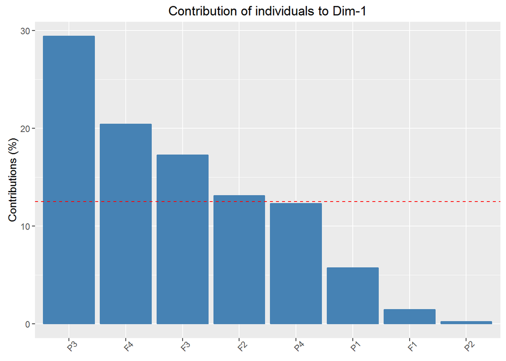

```r
fviz_pca_contrib(res.pca, choice = "ind", axes = 1)
```

Les produits P2(58.92%) et P1(23.12%) sont les produits qui contribuent le plus dans la construction de l’axe2.

```r
round(res.pca$ind$contrib[,2],digits=2)
```

```
##    F1    F2    F3    F4    P1    P2    P3    P4
##  5.03  1.65  0.02 10.47 23.12 58.92  0.14  0.66
```

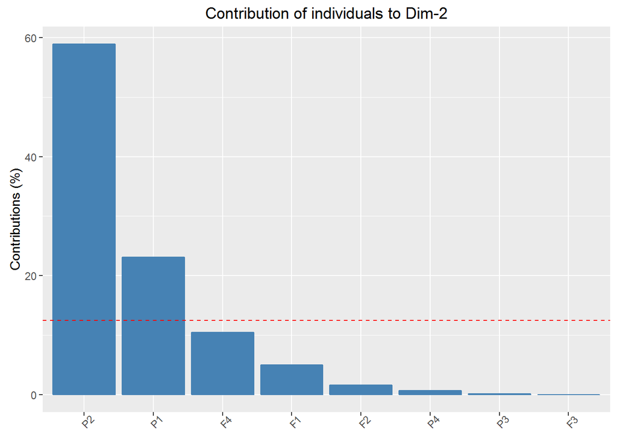

```
         **f) Contribution des descripteurs sensoriels :**
```

```r
fviz_pca_contrib(res.pca, choice = "ind", axes = 2)
```

Les variables Ovanille(10.44%),Gvanille(9),Tcraqcroust(8.19%),Vépaisseur(8.02),Ocaramel,Tfiriabilité,Tgransubal,Tfondant sont les variables qui contribuent le plus dans la construction de l’axe1 et les variables Gcitron,Ocitron,Olait,Glait sont les variables qui contribuent le plus dans la construction de l’axe2. De plus on a déjà interpreté dans la cercle de corrélation que la variable Vcouleur n’a aucun effet dans la construction de 2 axes principaux et c’est confirmé à travers les 2 graphes ci-dessous.

```r
round(res.pca$var$contrib[,1],digits = 2)
```

```
##    Vcouleur  Vépaisseur        Ouf       Olait     Obeurre    Ovanille
##        0.36        8.02        6.02        1.00        0.58       10.44
##    Ocaramel     Ocitron    Tdurcroq Tfriabilité  Tgranusabl   Tfarineux
##        8.00        0.01        0.04        7.58        7.39        3.67
## Tcraqcroust     Tpâteux    Tfondant       Gsalé      Gsucré        Guf
##        8.19        1.13        6.89        4.04        3.37        2.61
##       Glait     Gbeurre    Gvanille    Gcaramel     Gcitron
##        2.04        2.77        9.62        6.20        0.01
```

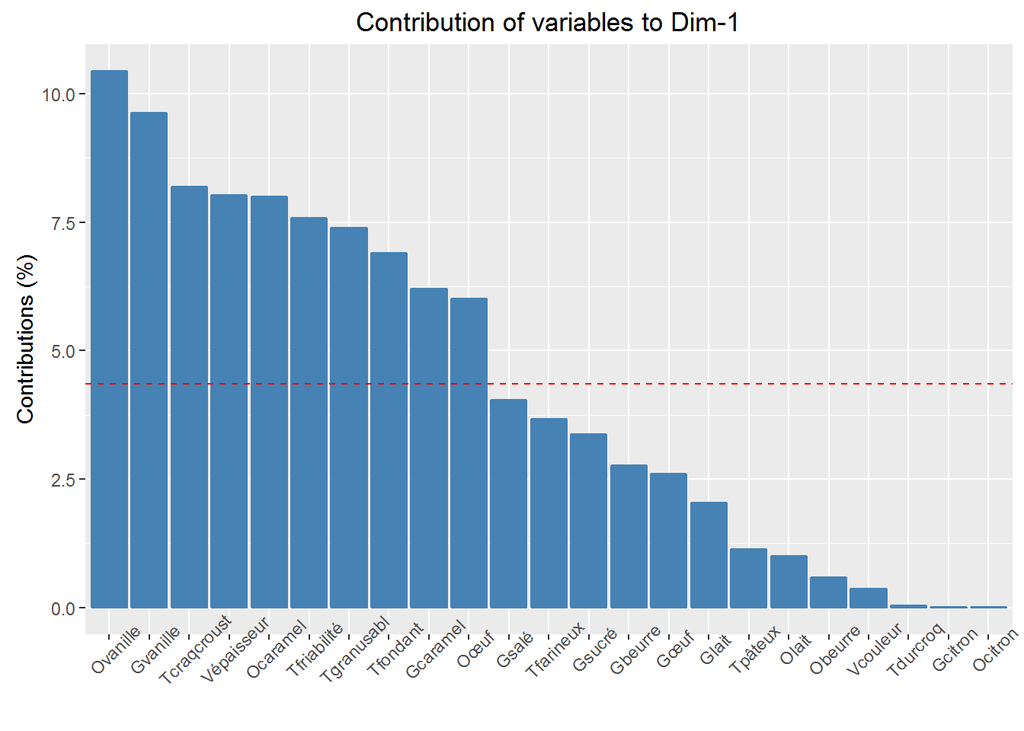

```r
fviz_contrib(res.pca , choice = "var", axes = 1)
```

```r
round(res.pca$var$contrib[,2],digits=2)
```

```
##    Vcouleur  Vépaisseur        Ouf       Olait     Obeurre    Ovanille
##        0.00        0.41        4.40       12.33        5.61        0.29
##    Ocaramel     Ocitron    Tdurcroq Tfriabilité  Tgranusabl   Tfarineux
##        0.14       14.41        2.21        5.00        0.23        2.25
## Tcraqcroust     Tpâteux    Tfondant       Gsalé      Gsucré        Guf
##        1.34        0.79        1.83        8.13        3.11        3.49
##       Glait     Gbeurre    Gvanille    Gcaramel     Gcitron
##       11.35        7.24        0.63        0.00       14.80
```

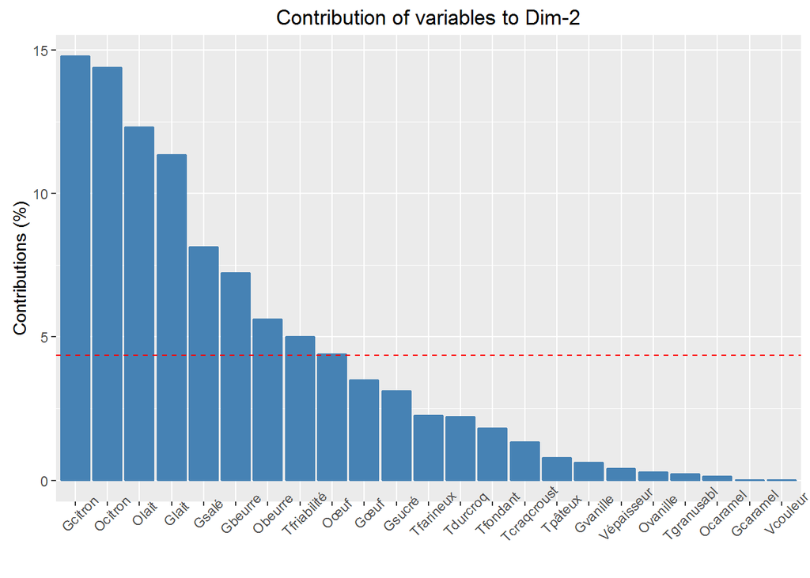

```
      **h) Représentation simultanée des produits et des descripteurs :**
```

```r
fviz_contrib(res.pca, choice = "var", axes = 2)
```

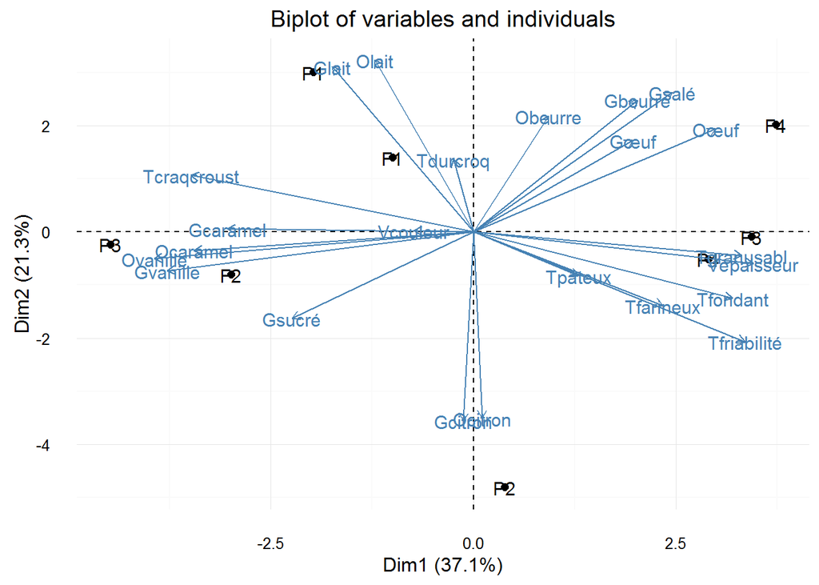

```r
fviz_pca_biplot(res.pca, geom=c("text","point"))+ theme_minimal()
```

# IV- Les Cartopographies de préferences :

**** L’objetcif de les cartographies des préférences c’est relier les préférences des consommateurs aux caractéristiques sensorielles d’un produit.

a/cartographie interne

***La cartographie interne nous permet de savoir les différences entre produits fondées sur les préférences des consommateurs puis mise en relation avec les caractéristiques sensorielles des produits.

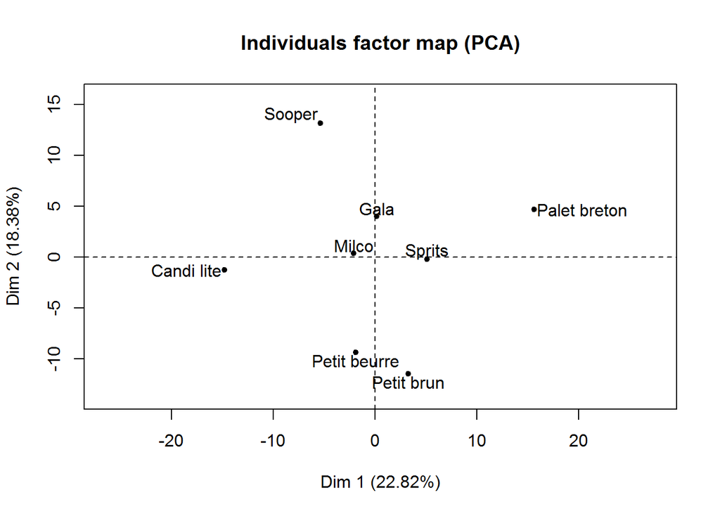

[figure not shown]

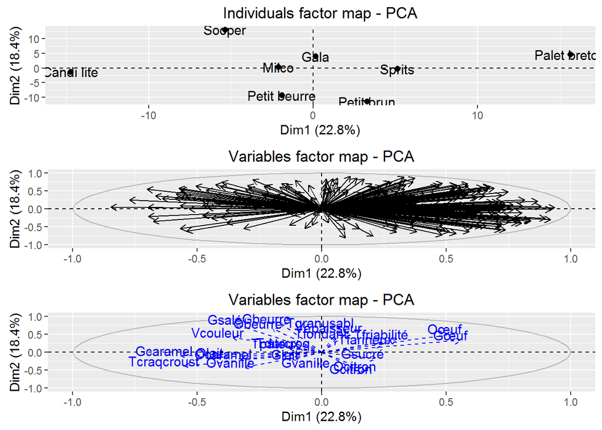

4/Classification et segmentation des consommateurs:

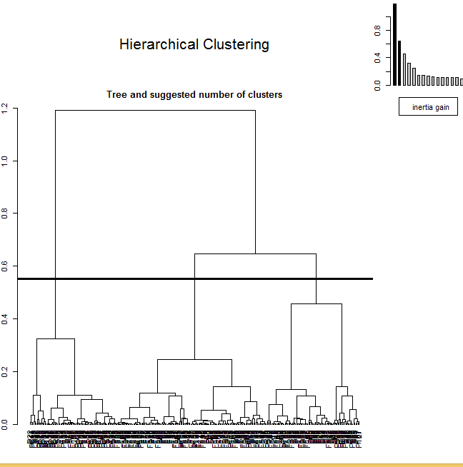

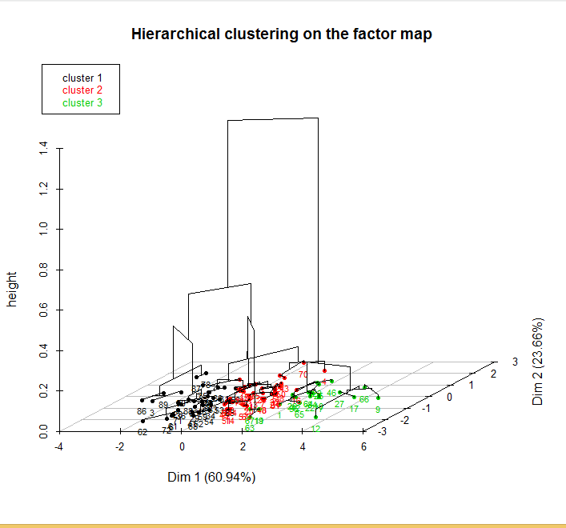

On peut classer les consommateurs en 3 classes.

5/Cartographie externe

*** c’est une méthode utilisée dans le domaine de recherche et dévelppement du marché pour explorer et comprendre les tendances des consommateurs.

*classe1:

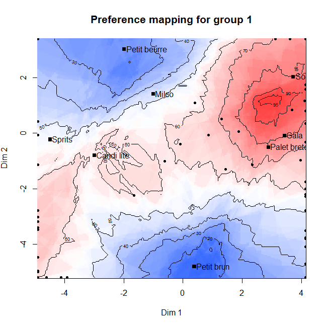

Pour la première classe on remarque que les biscuits Sooper ,Gala et Palet breton sont les plus préferés par les consommateurs , on a 80 consommateurs qui ont apprecié ces produits. Et pour le Candi lite il est moins apprecié avec 60 consommateurs qui ont aimé ce produit. Le Petit brun et le Petit beurre ce sont les produits que seulement 20 consommateurs ont apprecié .

*classe2: Pour la deuxième classe on remarque que les biscuits Petit brun ,Gala et Palet breton sont les plus préferés par les consommateurs , on a 80 consommateurs qui ont apprecié ces produits. Et pour le Petit beurre il est moins apprecié avec 60 consommateurs qui ont aimé ce produit. Pour le Candi lite seulement 20 consommateurs l’ont apprecié .

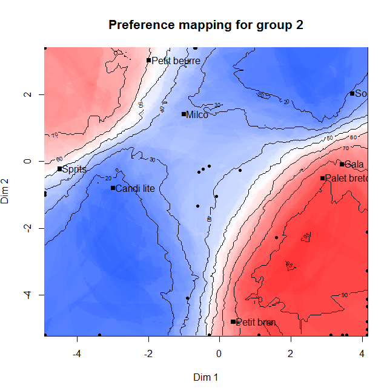

*classe3:

Pour la troisième classe on remarque que les biscuits Sooper,Gala et Palet breton sont les plus préferés par les consommateurs , on a 70 consommateurs qui ont apprecié ces produits. Le Milco et le Petit beurre ce sont les produits que seulement 50 consommateurs ont apprecié .

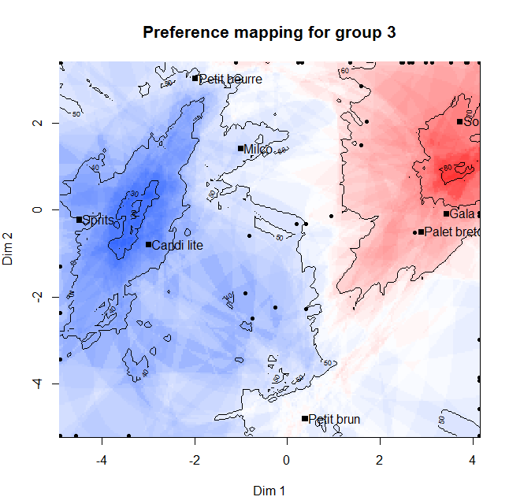

****On remarque que pour les 3 classes les préférences des consommateurs sont différentes .

*** Tous les consommateurs:

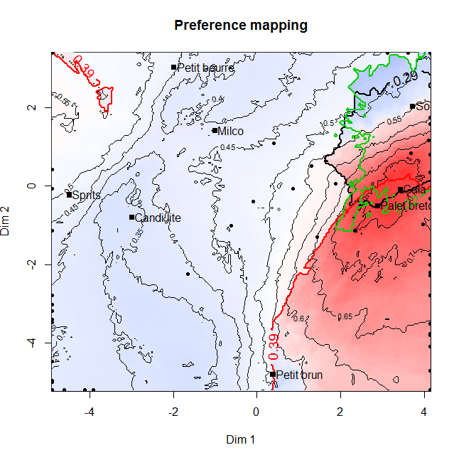

Cette carte est l’intersection des préférences des 3 classes , on peut conclure que le Gala et le Palet breton sont les produits les plus préférés par la plupart des consommateurs.

# Conclusion

Les résultats de cette étude peuvent nous être utiles à la comparaison des biscuits en mettant leur différence et de faire un classement , cela peut aussi aider à la définition d’un standard de qualité pour les biscuits .